# Data Validation Plan

### Quantitative Data Validation

- **GPP data: Country data validation and outcomes validaton**
- QRQ data validation

### Qualitative Checks

- Traditional qualitative cross-checks
- **Massive analysis using AI**
- Interviews with experts

# GPP Quantitative Validation

## Quantitative Validation

- Country data validation: Pretest
  - The pretest process occurs before the pooling companies start the collection of data. This aims to evaluate that all the material for the full fieldwork is correct
- Country data validation: Full fieldwork
  - After receiving data from pooling companies, we verify representativeness and alignment with each country’s patterns, warnings cannot be returned with pooling companies.
- Outcomes Validation
  - The final stage in our data verification process involves validating the estimated outcomes constructed with our dataset.

## Country data validation

- Sample Representativeness
- Patterns and Correspondence
- Sample distributions
  - By sociodemographic group
  - By NUTS and country level
- Missing values
- Difficulty score (Face-to-Face only)
- Internal checks (key variables)
  - Overtime changes (t-test)
  - Subnational rankings*
- External checks (Multilevel analysis)
  - Aggregated scores analysis (level 1)
  - Question level analysis (level 2)
  - Extreme outlier detection (level 3)

## Country data validation: Pretest

- Deliverable: A report document along with a supplementary Excel file for each country

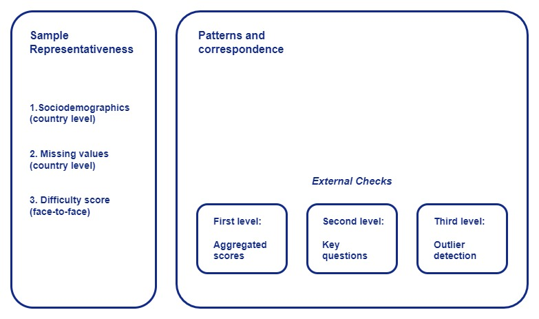

## Country data validation: Full fieldwork

- Deliverable: Internal report or platform summarizing flags and issues at the country level

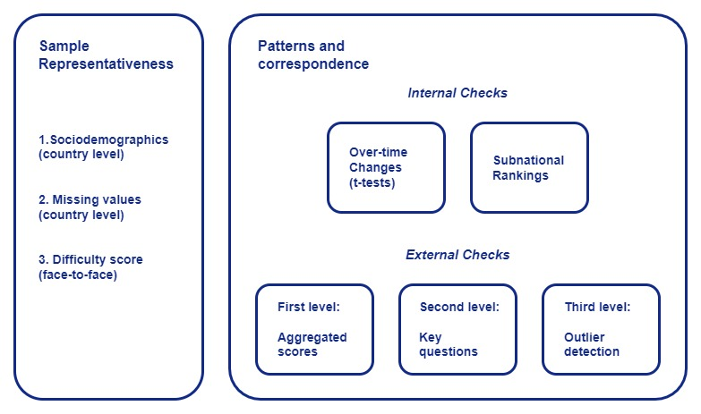

## Outcomes Validation

- Internal checks
  - Aggregated variables at the sub-national level and detect outliers among all 110 NUTS regions.
- External checks
  - Ranking comparisons validation between key variables from the GPP and selected TPS indicators

## Deliverables Desing

- Pretest data
  - A document highlighting the potential problematic variables
- Full fieldwork data
  - An HTML country report that will contain all the flags finding in the proposed analysis
  - Attach to the HTML will be included a complementary excel with all the analysis
- Outcomes Validation
  - The HTML serves as a complement to those generated following the full fieldwork collection
  - The HTML will primarily focus on presenting the results and highlighting problematic data points

# Task and Current Status

## Tasks

- Variables selection
- Validation coding
- Deliverables design

**Responsible:** Horacio and Gustavo  
**Support:** Data Analytics

- TPS selection (90%)
- Quasi-comparables matches (TPS-GPP) identification (80%)
- TPS recollection, data and cleaning (90%)

**Responsible:** Data Analytics  
**Support:** Natalia Rodriguez

- Country data validation programming (30%)
- Outcomes validation programming (0%)

**Responsible:** Data Analytics

- Design of reports and excels for Pretest (30%)
- Platform design and creation (0%)

## QRQ data validation

- Similar to the validation process carried out by the Index Team
- Focused on flagging individuals (outliers)
- Sensitivity analysis
  - How much do the scores change by dropping individuals/questions?
- Deliverable: an excel file similar to the map file used by the index team

# Massive analysis using AI: Overview

## Developing a news articles gathering and classification system

- Data collection trough a news data API
  - Access to a massive news data archive (1.000.000 articles per month)
  - Filter data by topic, newspaper and date
- Data labeling
  - WebApp to help team labeling data
- Model training
  - Machine Learning and Neural Networks (drip modelling)
  - AWS cloud computing (depends of the model)
- Model deployment (TBD)

## Implementing extensions (analysis)

- Topic Modeling Analysis
  - Identify number of topics, along with keywords and events for each one of them
- Summary of events
  - Automatic summaries of clustered news data
- Country/regional report
  - Summary of main news articles and events highligting key topic.